# nCov2019: A R package for studying COVID-19 coronavirus outbreak

Tianzhi Wu, Erqiang Hu, Patrick Tung, Xijin Ge, Guangchuang Yu

2021-04-02

To provide convenient access to epidemiological data on the coronavirus outbreak, we developed an R package, nCov2019 (https://github.com/yulab-smu/nCov2019). Besides detailed basis statistics, it also includes information about vaccine development and therapeutics candidates. We redesigned the function plot() for geographic maps visualization and provided a interactive shiny app. These analytics tools could be useful in informing the public and studying how this and similar viruses spread in populous countries.

Our R package is designed for both command line and dashboard interaction analysis, As show in diagram, while `dashboard()` is the main entry for the GUI explore part, the `query()` is the main function used in CLI explore part, 5 types of data were contain in its return result. Result type were explain in **Statistic query** part.

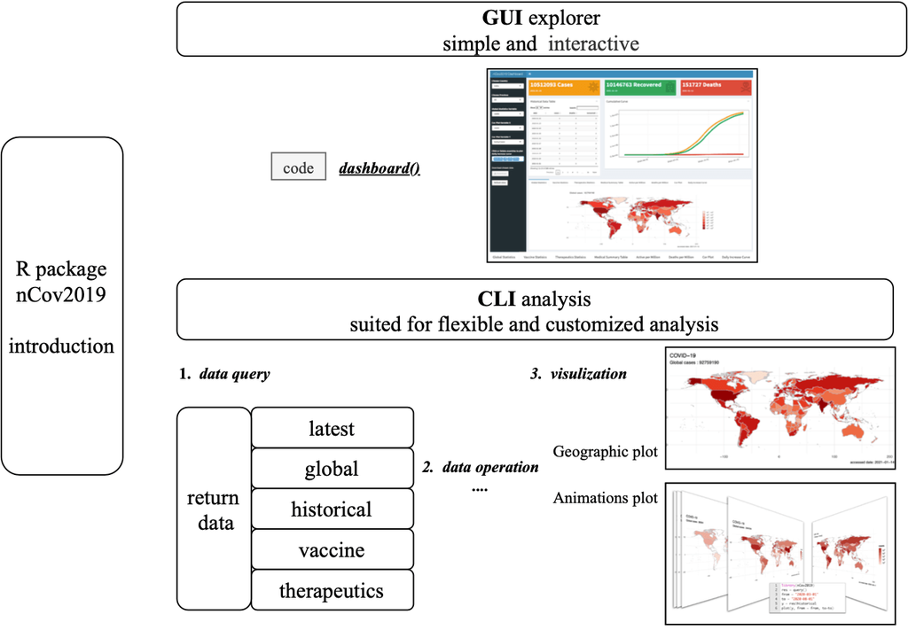

## Installation

To start off, users could utilize the ‘remotes’ package to install it directly from GitHub by running the following in R:

```r
remotes::install_github("yulab-smu/nCov2019", dependencies = TRUE)
```

## Statistic query

Data query is simple as one command:

```r
library("nCov2019")
res <- query()
```

```
## Querying the latest data...
```

```
## last update: 2021-04-02
```

```
## Querying the global data...
```

```
## Gloabl total  130174617  cases; and  2840184  deaths
## Gloabl total affect country or areas: 221
## Gloabl total recovered cases: 7609
## last update: 2021-04-02
```

```
## Querying the historical data...
```

```
## Querying the vaccine data...
```

```
## Total Candidates Programs : 51
```

```
## Querying the therapeutics data...
```

```
## Total Candidates Programs : 54
```

```
## Query finish, each time you can launch query() to reflash the data
```

This may take seconds to few minutes, which depend on the users’ network connection, if the user connection is broken, a local stored version data will be used for demo.

The result returned by `query()` function will contains 5 types of statistic:

```r
names(res)
```

```
## [1] "latest"       "global"       "historical"   "vaccine"      "therapeutics"
```

- `global` The global overall summary statistic
- `latest` The global latest statistic for all countries
- `historical` The historical statistic for all countries
- `vaccine` The current vaccine development progress
- `therapeutics` The current therapeutics development progress

The `query()` only need to be performed once in a session, print each of statistic objects, users could get their update time. And for the `vaccine` and `therapeutics` query results, print them will return the candidates number.

### Global data

The query result of global status will contain a data frame with 21 types of statistic, which have detail explanation on the bottom of this documents. And `summary(x)` will return overview of global status.

```r
x = res$global
x$affectedCountries # total affected countries
```

```
## [1] 221
```

```r
summary(x)
```

```
## Gloabl total  130174617  cases; and  2840184  deaths
## Gloabl total affect country or areas: 221
## Gloabl total recovered cases: 7609
## last update: 2021-04-02
```

### Latest data

Here is the example for operating latest data. once again, all data have queried and store in `res`.

```r
x = res$latest
```

And then `print(x)` will return the update time for the latest data

```r
print(x) # check update time
```

```
## last update: 2021-04-02
```

To subset latest data could be easily done by using `[`. `x["Global"]` or x`["global"]` will return the data frame for all countries but users could determine a specific country, such as:

```r
head(x["Global"]) # return all global countries.
```

```
##   country    cases deaths recovered  active todayCases todayDeaths
## 1  Brazil 12842717 325559  11239099 1278059      89459        3673
## 2   India 12302110 163428  11522884  615798      81441         468
## 3     USA 31244639 566611  23754391 6923637      76786         952
## 4  France  4695082  95976    296166 4302940      50659         314
## 5  Turkey  3357988  31713   3035043  291232      40806         176
## 6  Poland  2356970  53665   1882179  421126      35251         621
##   todayRecovered population     tests    updated
## 1          69162  213691728  28600000 2021-04-02
## 2          50390 1390160589 244798621 2021-04-02
## 3          80840  332457943 405032316 2021-04-02
## 4           1528   65381957  64823784 2021-04-02
## 5          20817   85018143  38821795 2021-04-02
## 6          20254   37815450  12145470 2021-04-02
```

```r
x[c("USA","India")] # return only for USA and India
```

```
##   country    cases deaths recovered  active todayCases todayDeaths
## 2   India 12302110 163428  11522884  615798      81441         468
## 3     USA 31244639 566611  23754391 6923637      76786         952
##   todayRecovered population     tests    updated
## 2          50390 1390160589 244798621 2021-04-02
## 3          80840  332457943 405032316 2021-04-02
```

The data is order by “todayCases” column, users could sort them by other order.

```r
df = x["Global"]
head(df[order(df$cases, decreasing = T),])
```

```
##    country    cases deaths recovered  active todayCases todayDeaths
## 3      USA 31244639 566611  23754391 6923637      76786         952
## 1   Brazil 12842717 325559  11239099 1278059      89459        3673
## 2    India 12302110 163428  11522884  615798      81441         468
## 4   France  4695082  95976    296166 4302940      50659         314
## 16  Russia  4554264  99233   4176419  278612       9169         383
## 32      UK  4350266 126764   3860174  363328       4478          51
##    todayRecovered population     tests    updated
## 3           80840  332457943 405032316 2021-04-02
## 1           69162  213691728  28600000 2021-04-02
## 2           50390 1390160589 244798621 2021-04-02
## 4            1528   65381957  64823784 2021-04-02
## 16          10247  145981477 120600000 2021-04-02
## 32          12823   68153448 127546869 2021-04-02
```

As for the latest data, it provides 11 types of main information by default, but 12 more statistic type are provided in the “latest$detail”, they also have corresponding explanation on the bottom.

```r
x = res$latest
head(x$detail)  # more detail data
```

```
##      updated country countryInfo._id countryInfo.iso2 countryInfo.iso3
## 1 2021-04-02  Brazil              76               BR              BRA
## 2 2021-04-02   India             356               IN              IND
## 3 2021-04-02     USA             840               US              USA
## 4 2021-04-02  France             250               FR              FRA
## 5 2021-04-02  Turkey             792               TR              TUR
## 6 2021-04-02  Poland             616               PL              POL
##   countryInfo.lat countryInfo.long                           countryInfo.flag
## 1             -10              -55 https://disease.sh/assets/img/flags/br.png
## 2              20               77 https://disease.sh/assets/img/flags/in.png
## 3              38              -97 https://disease.sh/assets/img/flags/us.png
## 4              46                2 https://disease.sh/assets/img/flags/fr.png
## 5              39               35 https://disease.sh/assets/img/flags/tr.png
## 6              52               20 https://disease.sh/assets/img/flags/pl.png
##      cases todayCases deaths todayDeaths recovered todayRecovered  active
```

[output cut: 27 more lines]

### Historical data

Historical data is useful in retrospective analysis or to establish predictive models, the operation is similar as latest data, user could get the data frame for all countries or some specific countries within `c()` vector, such as `head(Z[c(country1,country2,country3)])`

```r
Z = res$historical
print(Z) # update time
```

```
## last update: 2021-03-31
```

```r
head(Z["Global"])
```

```
##         country       date cases deaths recovered
## 1   Afghanistan 2020-01-22     0      0         0
## 193 Afghanistan 2020-01-23     0      0         0
## 385 Afghanistan 2020-01-24     0      0         0
## 577 Afghanistan 2020-01-25     0      0         0
## 769 Afghanistan 2020-01-26     0      0         0
## 961 Afghanistan 2020-01-27     0      0         0
```

```r
head(Z[c("China","UK","USA")])
```

```
##     country       date cases deaths recovered
## 37    China 2020-01-22   548     17        28
## 229   China 2020-01-23   643     18        30
## 421   China 2020-01-24   920     26        36
## 613   China 2020-01-25  1406     42        39
## 805   China 2020-01-26  2075     56        49
## 997   China 2020-01-27  2877     82        58
```

For the following countries, we provide detail province data, which can be obtained in a similar way but within `[` operation: `head(Z[country,province])`

- `Australia` `Canada` `China` `Denmark` `France` `Netherlands`

```r
 head(Z['China','hubei'])
```

```
##     country province       date cases deaths recovered
## 34    China    hubei 2020-01-22   444     17        28
## 119   China    hubei 2020-01-23   444     17        28
## 204   China    hubei 2020-01-24   549     24        31
## 289   China    hubei 2020-01-25   761     40        32
## 374   China    hubei 2020-01-26  1058     52        42
## 459   China    hubei 2020-01-27  1423     76        45
```

For users’ own historical data, we provide a `convert()` function, users could convert other data into class of nCov2019History data, and then explore in nCov2019:

```r
userowndata <- read.csv("path_to_user_data.csv")
# userowndata, it should contain these 6 column:
# "country","province","date","cases","deaths","recovered"
Z = convert(data=userowndata)
head(Z["Global"])
```